# Clase 3 - Visualizando colores, cantidades, proporciones y distribuciones

## Distribuciones

### Un clásico: el histograma

La visualización por excelencia para mostrar distribuciones es el histograma, que en la práctica es una variante de… ¡gráfico de barras!.

Hacer un histograma es simple. Por ejemplo, para mostrar cómo se distribuye la variable “precio_unidad” la asignamos a las `x` y usamos `geom_histogram()`:

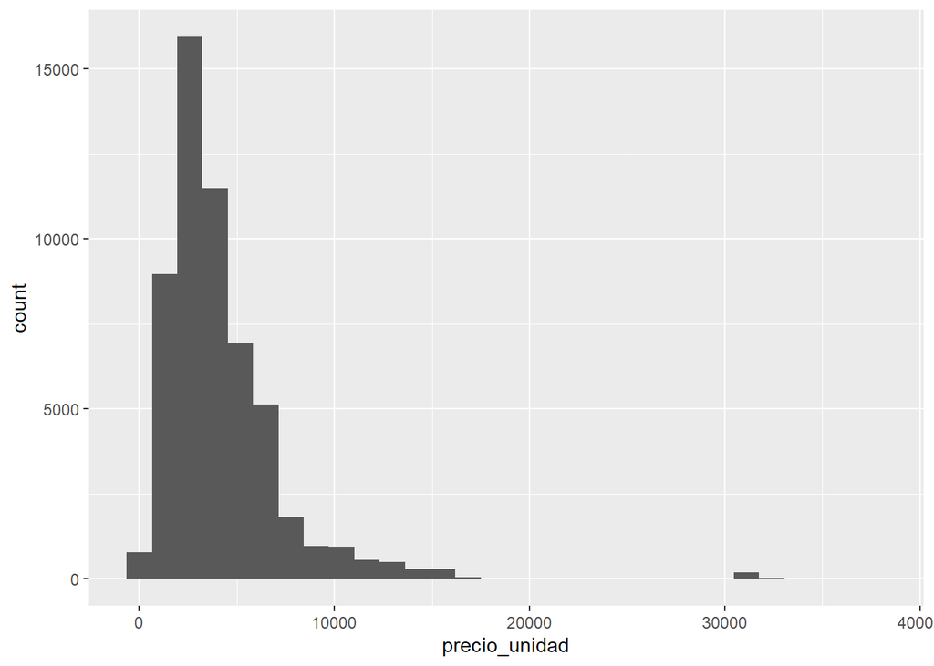

```r
ggplot(menstru_24_toallitas, aes(x = precio_unidad)) +
  geom_histogram()
```

Algo para advertir sobre los histogramas es que su aspecto (y con ello, el mensaje que dan) puede cambiar de acuerdo a la cantidad de intervalos que se usen. Por defecto `geom_histogram()` divide al rango de valores en 30 “bins” o intervalos iguales (por ejemplo “de 0 a 10”, “de 10 a 20”, etc) y cuenta cuántas observaciones caen en cada uno. Podemos controlar la cantidad de intervalos con el parámetro `bins`. También, podemos aumentar el nivel de detalle del histograma incrementando la cantidad de intervalos, a costa de perder generalización. Y a la inversa: si reducimos el nivel de intervalos, mostramos una distribución más resumida de la data, a costa de perder detalle.

Juguemos con los valores de `bins` para ver como cambia el resultado. ¿Y cuál es el número ideal de intervalos? Depende de las características de cada dataset y de lo que queremos mostrar… ¡no hay una sola respuesta correcta! Para este caso, probemos 50 bins:

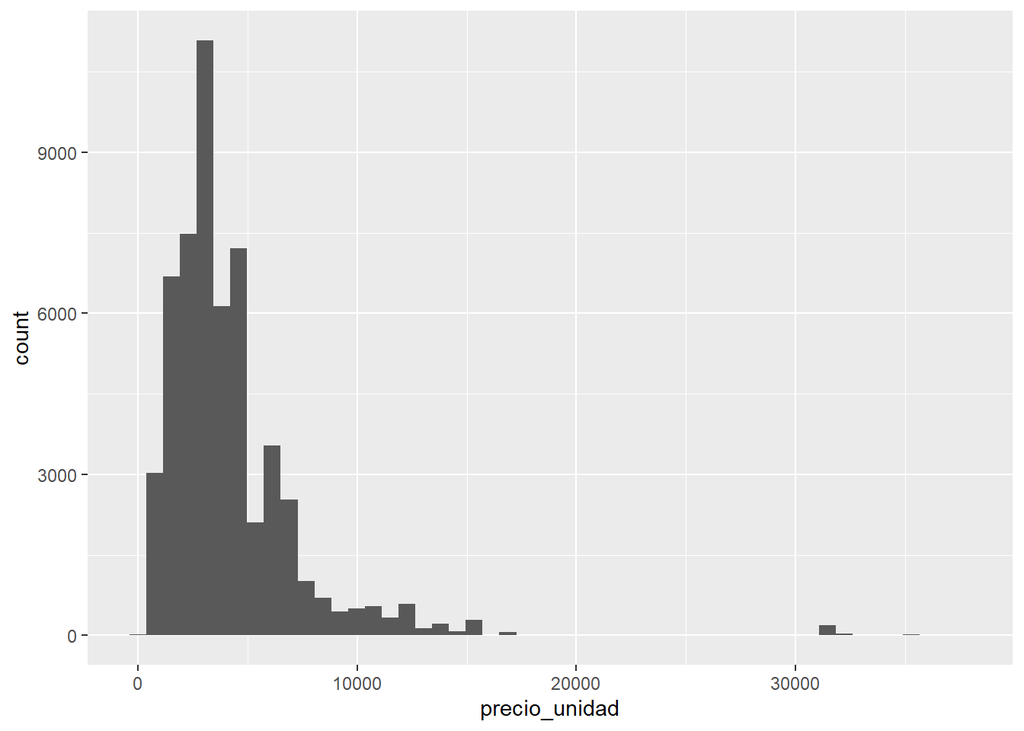

```r
ggplot(menstru_24_toallitas, aes(x = precio_unidad)) +
  geom_histogram(bins = 50)
```

### El gráfico de densidad

Los gráficos de densidad son descendientes directos de los histogramas. Pero en lugar de conteos de observaciones por rango de valores, lo que muestran es la distribución de *probabilidad* de la variable. Es decir, qué tan probable es encontrar un valor determinado si tomáramos al azar una de las observaciones. A diferencia de los histogramas, que llevan un par de siglos en uso porque porque son relativamente fáciles de hacer a mano, los (antes) trabajosos gráficos de densidad se han popularizado con la llegada de software y computadoras capaces de realizarlos en un instante.

Los gráficos de densidad se hacen de forma análoga a los histogramas, reemplazando `geom_histogram()` `geom_density()`. Probemos con los valores de “precio_unidad” en la región Patagónica.

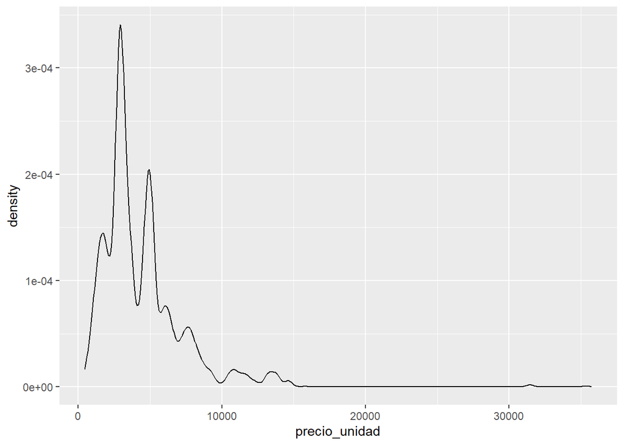

```r
ggplot(menstru_24 %>% filter(region == "PAT"), aes(x = precio_unidad)) +
  geom_density()
```

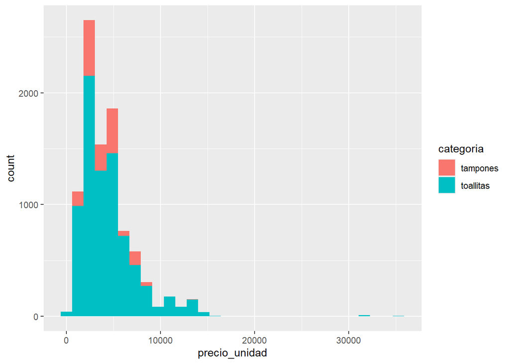

```r
ggplot(menstru_24 %>% filter(region == "PAT"), aes(x = precio_unidad, fill = categoria)) +
  geom_histogram()
```

¡El resultado es un lío! Las barras apiladas no son ideales para interpretar distribuciones. Las cosas mejoran un poco si usamos `position = "dodge"`, pero no mucho:

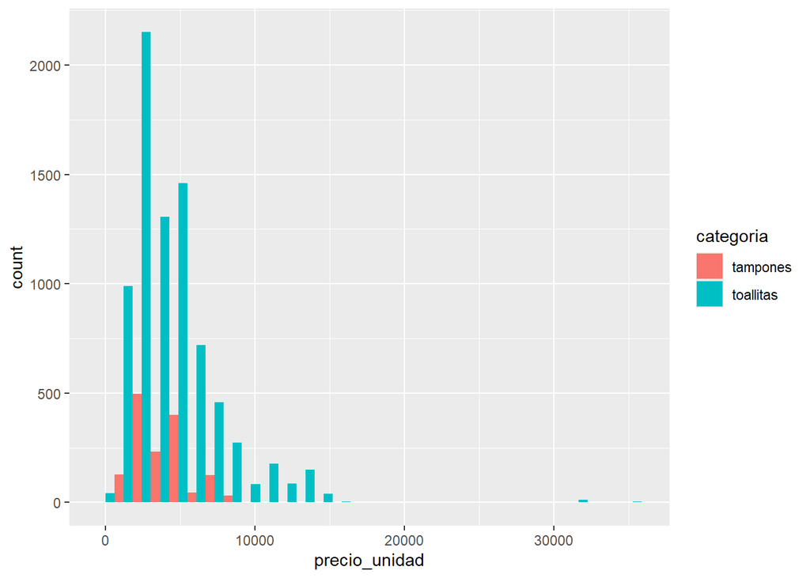

```r
ggplot(menstru_24 %>% filter(region == "PAT"), aes(x = precio_unidad, fill = categoria)) +
  geom_histogram(position = "dodge")
```

Probemos ahora usando `geom_density()`:

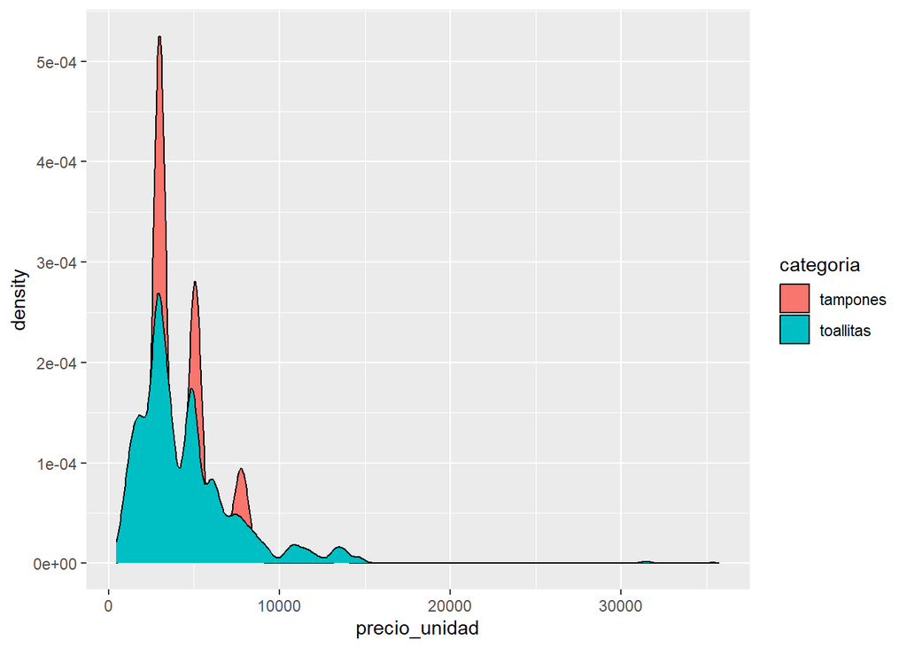

```r
ggplot(menstru_24 %>% filter(region == "PAT"), aes(x = precio_unidad, fill = categoria)) +
  geom_density()
```

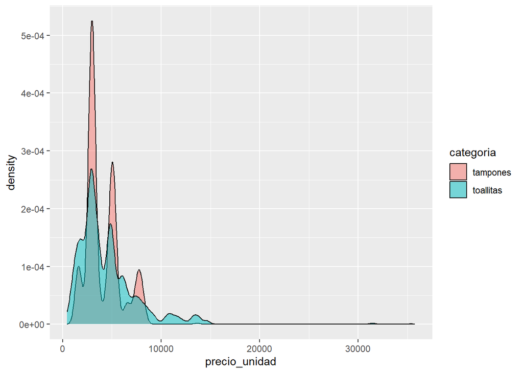

```r
ggplot(menstru_24 %>% filter(region == "PAT"), aes(x = precio_unidad, fill = categoria)) +
  geom_density(alpha = 0.5)
```

### Boxplots

Volvamos a nuestras visualizaciones de distribución. Ya hicimos histogramas (con `geom_histogram()`) y gráficos de densidad (con `geom_density()`), pero ahora vamos a usar un “boxplot”.

`geom_boxplot()` crea *boxplots* (o [“diagramas de caja”](https://economipedia.com/definiciones/diagrama-de-caja.html)).

Los boxplots pueden interpretarse como un histograma al que se lo ha colgado “de cabeza”, y luego resumido mostrando su hitos:

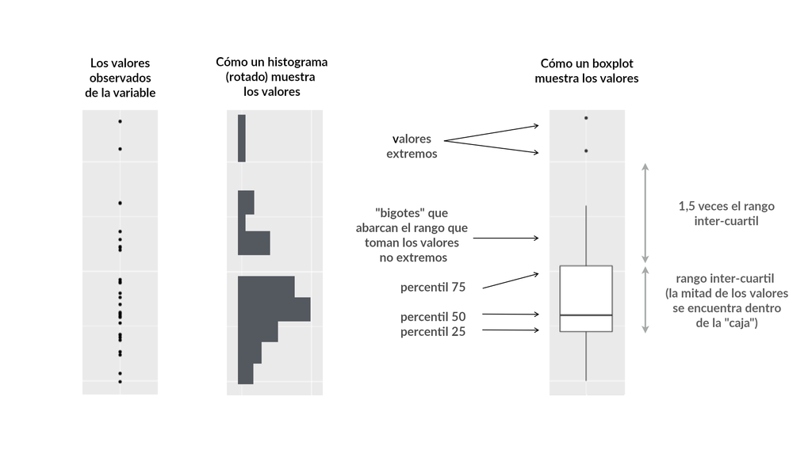

Es útil cuando queremos comparar distribuciones entre grupos (por ejemplo, categorías de producto o provincias). En general, ubicamos la variable categórica en el eje $x$ y la variable numérica en el eje $y$.

¡Hagamos eso mismo! Pongamos `categoria` en el eje $x$ (como variable categórica), `precio_unidad` en el eje de las $y$, y a dibujar cajas con `geom_boxplot()`.

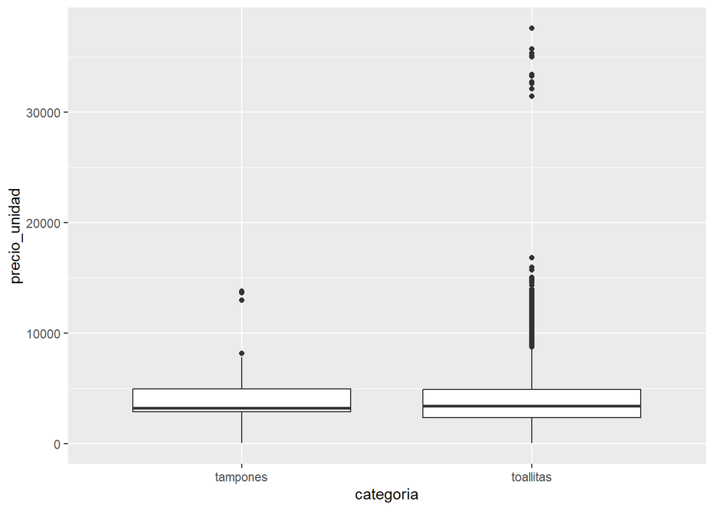

```r
ggplot(menstru_24 %>% filter(categoria %in% c("toallitas", "tampones")),
       aes(x = categoria, y = precio_unidad)) +
  geom_boxplot()
```

¿Qué pasa si lo damos vuelta?

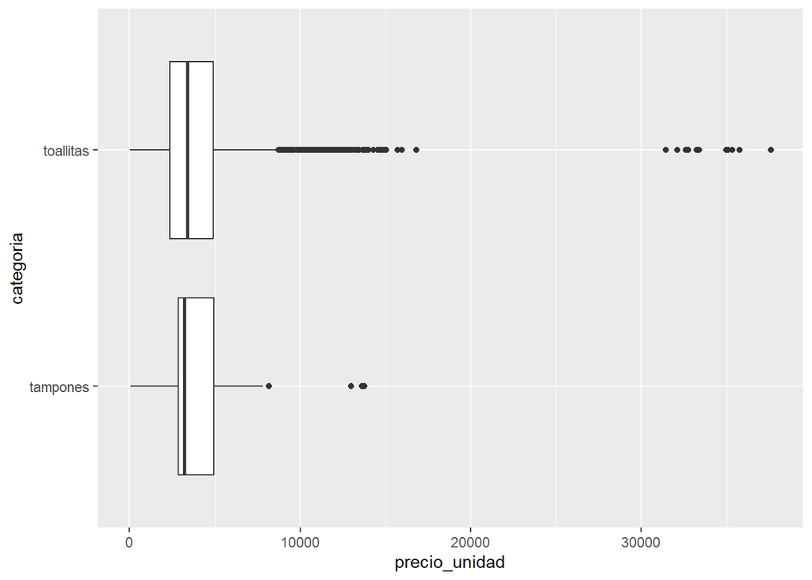

```r
ggplot(menstru_24 %>% filter(categoria %in% c("toallitas", "tampones")),
       aes(x = precio_unidad, y = categoria)) +
  geom_boxplot()
```

¿Cómo nos quedaría con la paleta viridis?

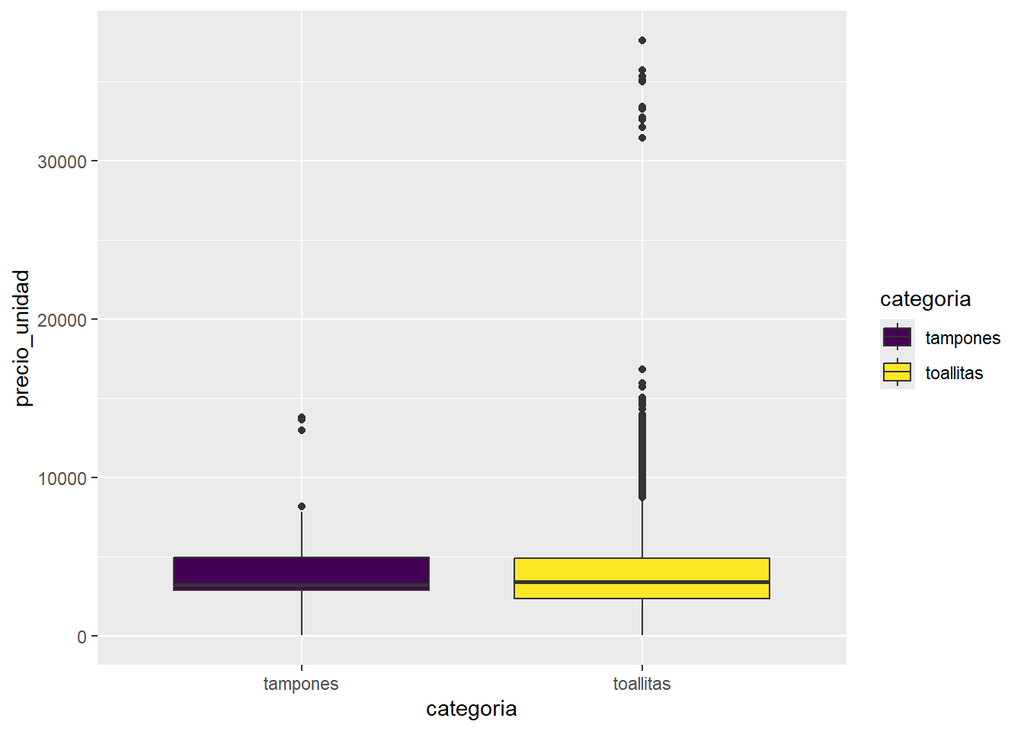

```r
ggplot(menstru_24 %>% filter(categoria %in% c("toallitas", "tampones")),
       aes(y = precio_unidad, x = categoria, fill =categoria)) +
  geom_boxplot() +
  scale_fill_viridis_d()
```

Ahora asignemos el color como atributo dependiente de la categoria, pero dejemos el color de las líneas fijo en color azul marino (`"navy blue"`) de acuerdo a los [nombres de colores que R sabe interpretar](http://www.stat.columbia.edu/~tzheng/files/Rcolor.pdf)

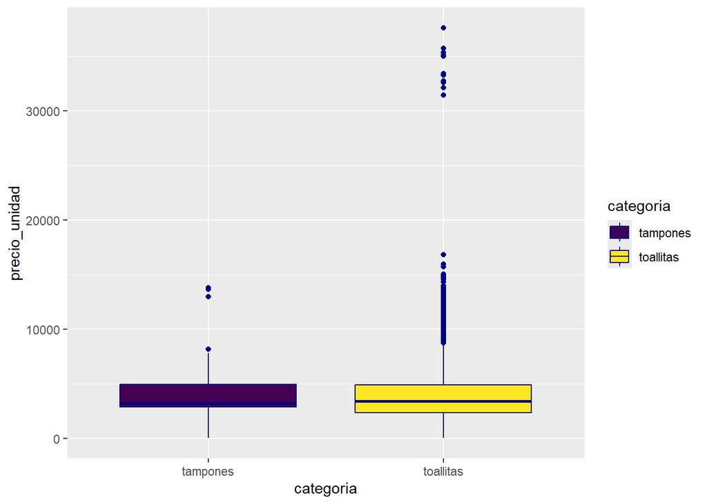

```r
ggplot(
  menstru_24 %>% filter(categoria %in% c("toallitas", "tampones")),
  aes(x = categoria, y = precio_unidad, fill = categoria)
) +
  geom_boxplot(color = "navyblue") +
  scale_fill_viridis_d()
```

Ahora al revés, asignemos la variable `categoria` al color de las líneas, pero dejemos el relleno de las cajas fijo en color `"navyblue"`.

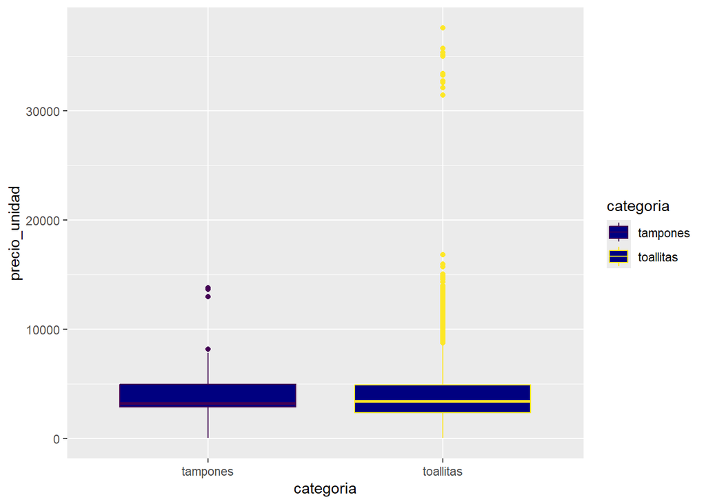

```r
ggplot(menstru_24 %>% filter(categoria %in% c("toallitas", "tampones")),
       aes(x = categoria, y = precio_unidad, color = categoria)) +
  geom_boxplot(fill = "navyblue") +
  scale_color_viridis_d()
```

El gráfico que obtuvimos funciona como recordatorio de que en muchas ocasiones la cantidad de recursos visuales volcados resulta inversamente proporcional a su legibilidad.

Si bien, en general simple es bueno, también conviene saber que podemos combinar varias estéticas dentro de `aes()` cuando resulte necesario.

### Facetados

Otra manera de mostrar comparaciones entre categorías es a través de los facetados, con las variantes de la función `facet_wrap()`. La función original, provista por ggplot, nos permite seleccionar una variable para desagruparla y graficarla en varios paneles. Pero a partir de esta función original se crearon otras variantes que nos permiten, por ejemplo, hacer zoom en un área determinada del gráfico.

Hagamos un gráfico de densidad de los precios de toallitas en las regiones Pampeana y Patagónica:

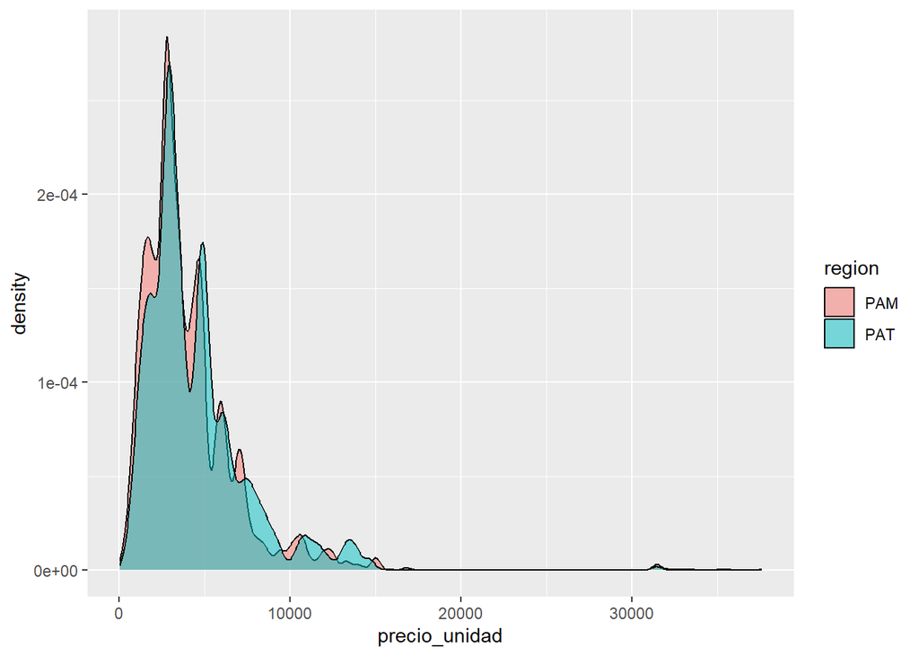

```r
ggplot(menstru_24_toallitas %>% filter(region == "PAT" | region == "PAM"), aes(x = precio_unidad, fill = region)) +
  geom_density(alpha = 0.5)
```

Es difícil ver las diferencias entre los precios con mayor probabilidad ya que algunos outliers achican el gráfico. Para hacer un zoom entre los precios más comunes, puedo usar la función `facet_zoom()` del paquete `ggforce`. Sólo tengo que pasarle al parámetro `xlim` los valores donde quiero que haga ese zoom.

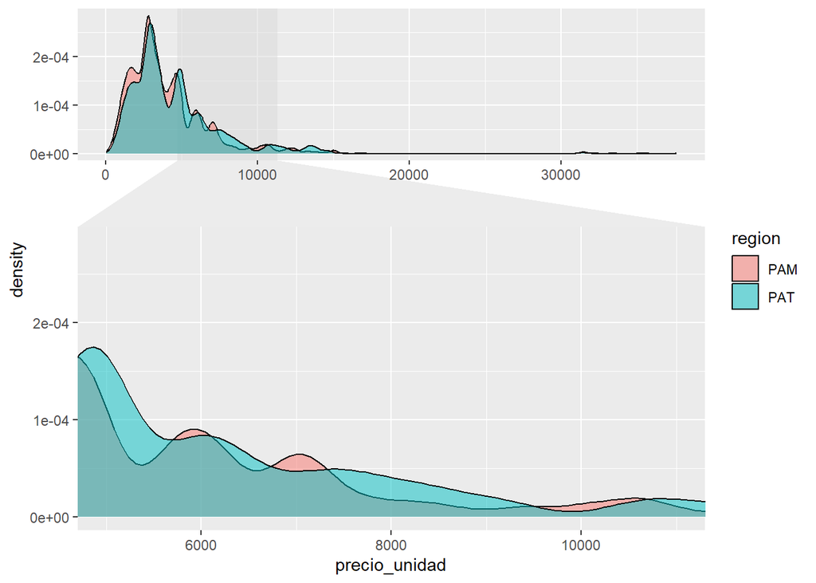

```r
library(ggforce)

ggplot(menstru_24_toallitas %>% filter(region == "PAT" | region == "PAM"), aes(x = precio_unidad, fill = region)) +
  geom_density(alpha = 0.5)+
  facet_zoom(xlim = c(5000, 11000))
```

Ahora bien, supongamos que quisiera ver la distribución de probabilidad para toallitas y tampones, para ver si ambas tienen una dispersión similar. Puedo usar la función `facet_wrap()`, a la cual le tengo que pasar con la función `vars()` el nombre de la variable por la cual se va a ordenar el facetado. En este caso, “Categoría”.

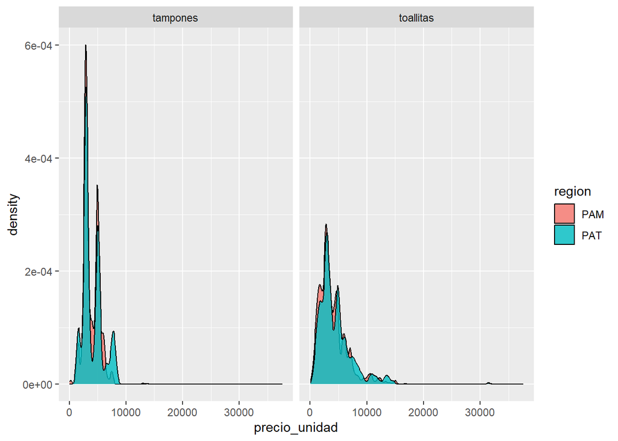

```r
ggplot(menstru_24 %>% filter(region == "PAT" | region == "PAM"), aes(x = precio_unidad, fill = region)) +
  geom_density(alpha = 0.8)+
  facet_wrap(vars(categoria))
```

A este gráfico se le pueden hacer varias mejoras.

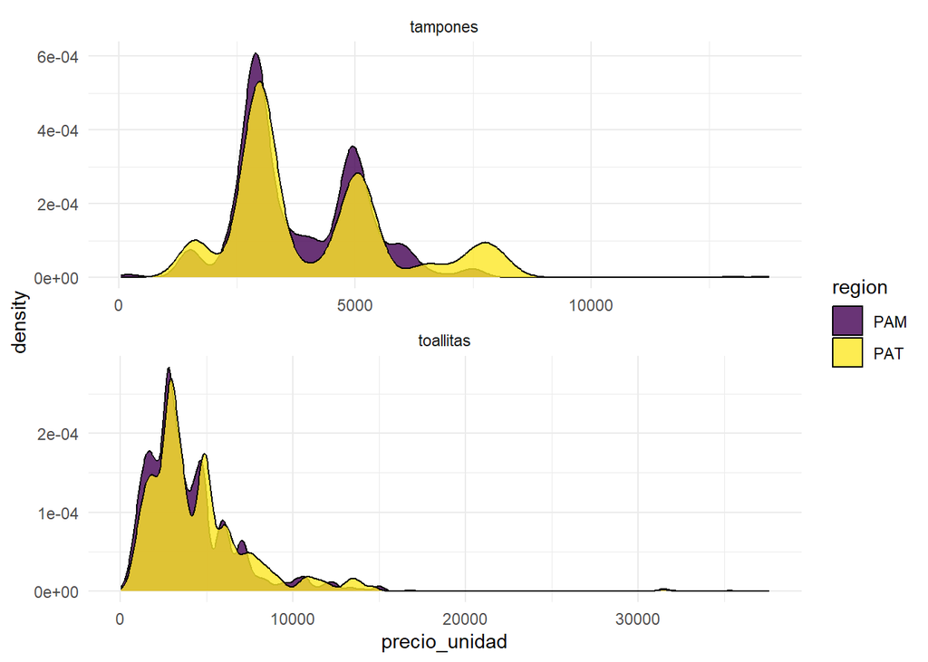

```r
library(viridis)

ggplot(menstru_24 %>% filter(region == "PAT" | region == "PAM"), aes(x = precio_unidad, fill = region)) +
  geom_density(alpha = 0.8)+
  facet_wrap(vars(categoria),
             nrow=2,
             scales = 'free')+
  theme_minimal()+
  scale_fill_viridis_d()
```

### ¡Y mas!

Existen muchas, muchas otras formas de comparar cantidades, distribuciones y proporciones. Por ejemplo, tenemos [“ridgeline plots”](https://r-charts.com/es/distribucion/ggridges/) que son otra buena alternativa para mostrar gráficos de densidad de forma ordenada:

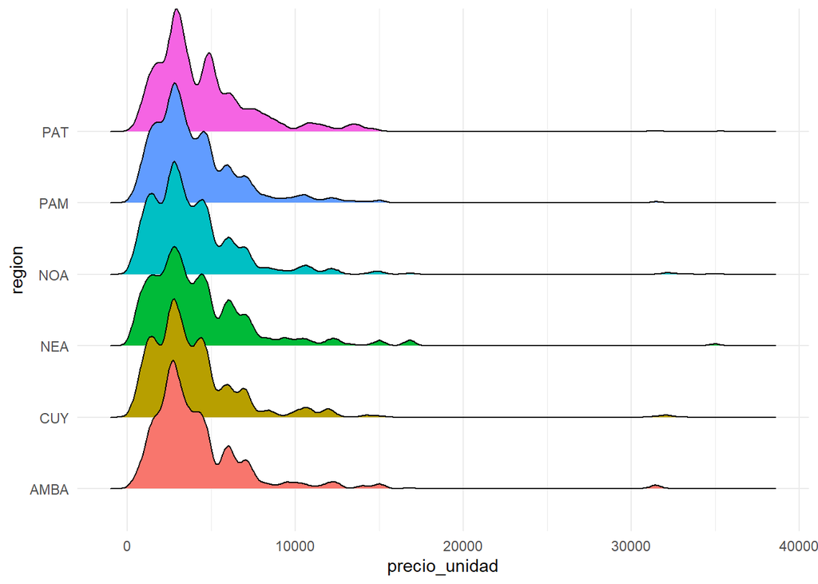

```r
library(ggridges)
library(ggplot2)

ggplot(menstru_24_toallitas , aes(x = precio_unidad, y = region, fill = region)) +
  geom_density_ridges() +
  theme_minimal() +
  theme(legend.position = "none")
```

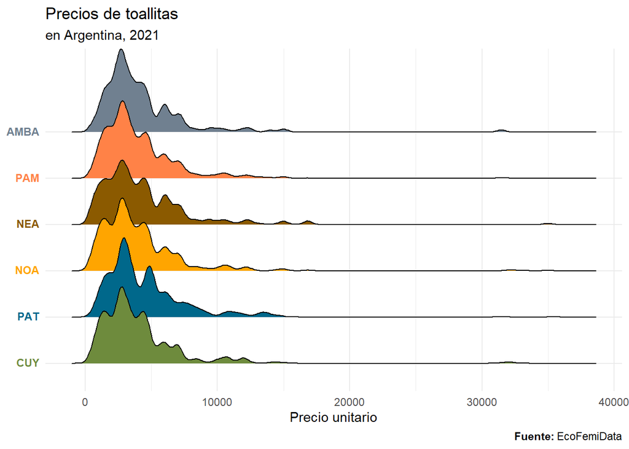

```r
library(ggtext)
library(glue)

menstru_24_toallitas %>%
  mutate(color = case_when(
    region == "PAT" ~ "deepskyblue4",
    region == "AMBA" ~ "slategrey",
    region == "NOA" ~ "orange",
    region == "NEA" ~ "orange4",
    region == "PAM" ~ "sienna1",
    region == "CUY" ~ "darkolivegreen4"
  ),
  name = glue("<b style='color:{color}'>{region}")) %>%
  ggplot(aes(x = precio_unidad, y = name, fill = color)) +
  geom_density_ridges() +
  scale_fill_identity()+
  labs(title = "Precios de toallitas",
       subtitle = "en Argentina, 2021",
       x = "Precio unitario",
       caption = "**Fuente:** EcoFemiData")+
  theme_minimal() +
  theme(legend.position = "none",
        plot.caption = element_markdown(lineheight = 1.2),
        axis.text.y = element_markdown(),
        axis.title.y = element_blank())
```

Para seguir leyendo sobre la visualización de cantidades, proporciones y distribuciones tienen nada menos que los capítulos [7](https://clauswilke.com/dataviz/histograms-density-plots.html), [8](https://clauswilke.com/dataviz/ecdf-qq.html) y [11](https://clauswilke.com/dataviz/nested-proportions.html) de *Fundamentals of Data Visualization* por Claus Wilke.